# Market General Report

2024-2025 Seasons

February 03, 2026

# 1 Dependencies

- 1.0_Data_Pre_Processing.Rmd
- 1.1_Calendar_Generation.Rmd
- 1.3_Order_Data_Variable_Selection.Rmd

# 2 Overview

## 2.1 Key variables

- order = one transaction with one customer
- item_name = singular item, entered multiple times/per order if multiple of one item purchased
- item_price = price for one item
- item_gross_amount = total cost before deductions
- item_total_discount = discount rounded to nearest cent
  - item_disc_amount_from_perc and item_net_discount_amount are not rounded to nearest percent.
- item_net_amount = cost after deductions

Should be case:

> item_gross_amount - item_total_discount = item_net_amount

```
## [1] 1650
```

**Variables with issues:**

- order_net
- order_profit
- order_amount_collected

A bunch of item_name “Manual Transactions” with negative order_amount_collected

**Not used/No Data:**

- item_cost
- order_tax
- order_tip_amount
- order_tip_amount_refund
- order_service_charge
- order_non_revenue_amount

**Used sometimes, but has issues:**

- order_item_cost
- order_item_cost_and_tax

# 3 Yearly metrics

|  | 2024 | 2025 |
| --- | --- | --- |
| records | 315,816 | 321,432 |
| orders | 1 | 1 |
| gross | 2,019,056 | 2,145,269 |
| net | 2,007,916 | 2,129,235 |
| discounts | 10,944 | 15,234 |
| ave_items_per_order | 315,816 | 321,432 |
| ave_gross_per_order | 2,007,916 | 2,129,235 |

Number of Items by Category

| category | 2025 | 2024 | difference |
| --- | --- | --- | --- |
| Produce | 180756 | 61171 | 119585 |
| Uncategorised | 12347 | 142204 | -129857 |
| Baked Goods | 52917 | 50658 | 2259 |
| Fall Seasonal | 19958 | 12612 | 7346 |
| Meat, Eggs, Dairy | 14376 | 12000 | 2376 |
| Jarred | 9422 | 8643 | 779 |
| Drinks | 7071 | 6795 | 276 |
| Treats | 6658 | 5555 | 1103 |
| PYO Pumpkins | 6099 | 5977 | 122 |
| Entrees | 4113 | 4148 | -35 |

[output cut: 5 more lines]

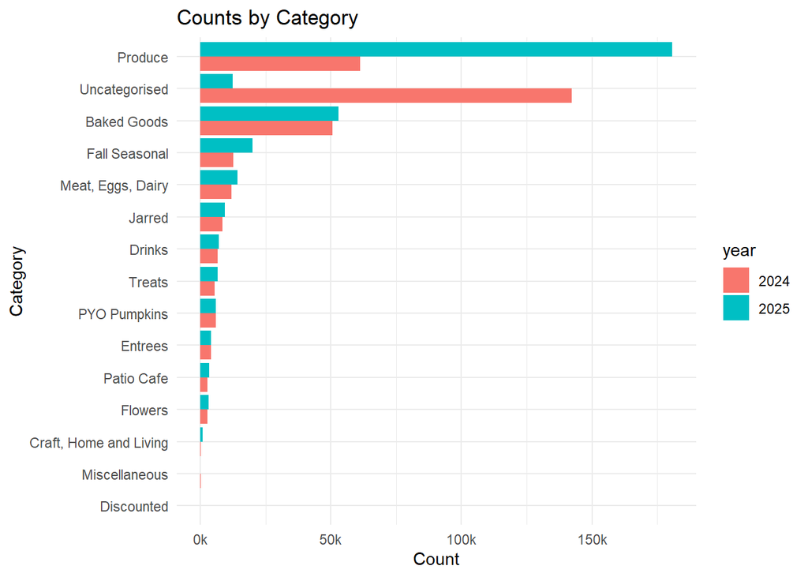

**Observations:**

- Marked improvement in categorization to 2025.
- Baked goods seem appropriately categorized

# 4 Gross Revenue by Date

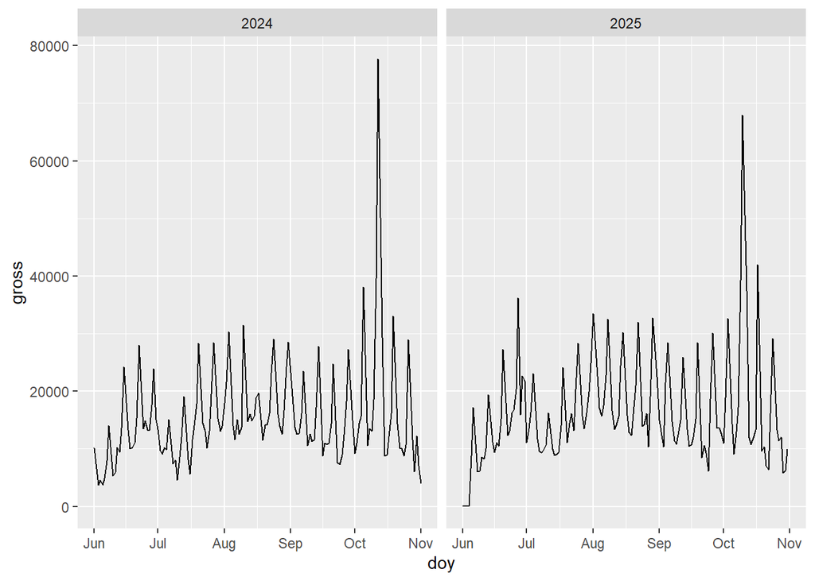

**Note**:

- removing two dates start of 2025 season
  - 2025-06-02 - 2 records
  - 2025-06-05 - 5 records

# 5 Weekly Analyis

For studying seasonal effects

## 5.1 Weekly Gross Sales

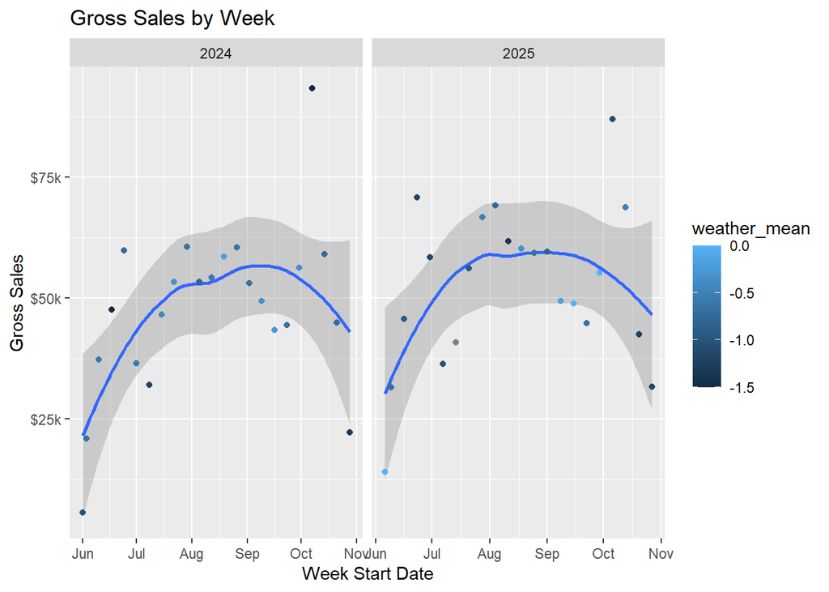

**Conclusions:**

- We have clear indication to use quadratic for modeling week of season effects.
- Bad weather week of Canadian Thanksgiving doesn’t appear to impact sales
- In fact, average weather is not great indicator across season

## 5.2 Weekly Orders (Transactions per week)

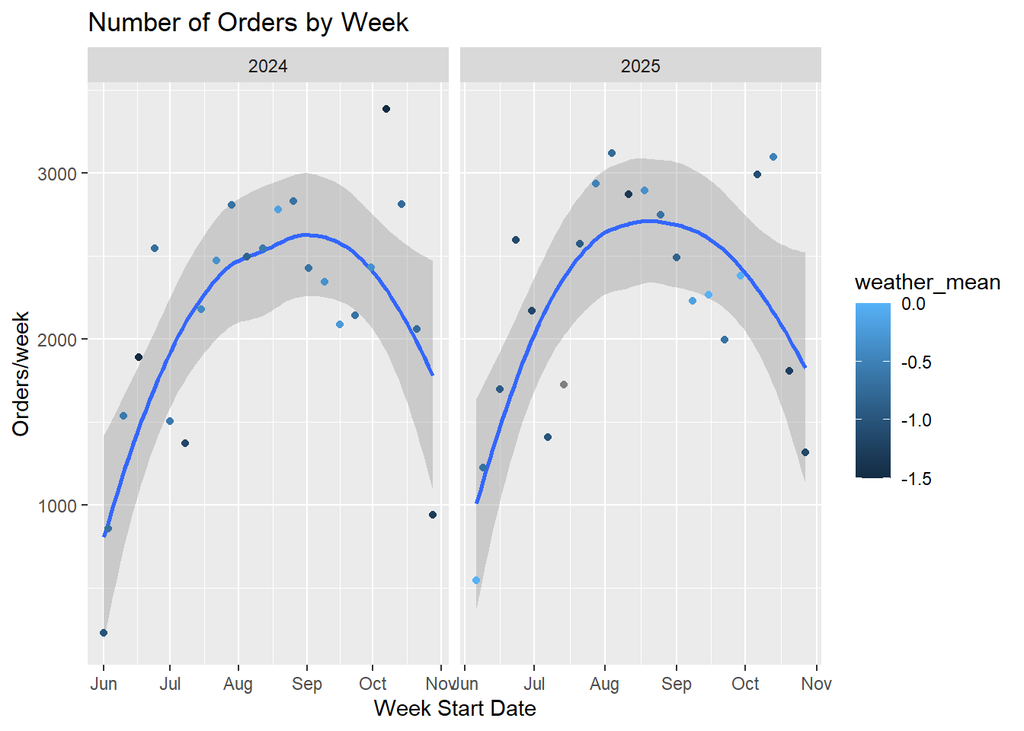

## 5.3 Weekly Average Sales per Order

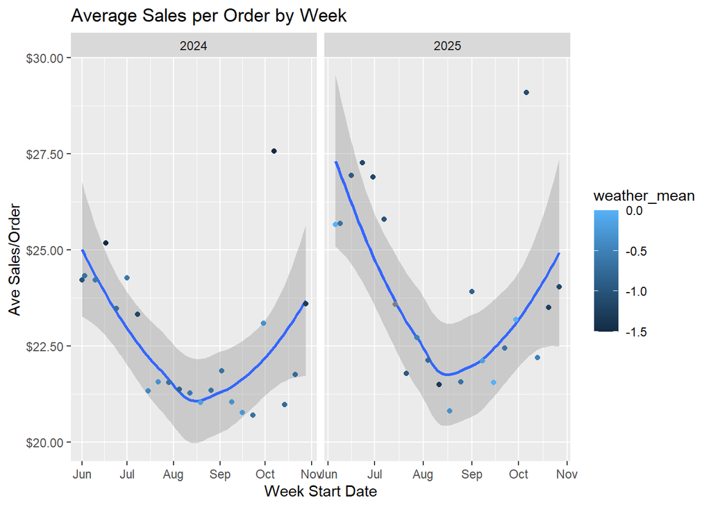

**Notes:**

- Higher traffic mid season, lower average orders
  - due to produce sales?
  - other factors
- Strategies to increase size of orders mid-season
  - study small/single item orders
  - market analysis for items that complementary reason for those visits
- I imagine loyal customers are more consistent though out the season
  - ways to track individual customers - large number number use electronic payment
  - use that data to study what promotes customer loyalty

## 5.4 Weekly Total Discounts

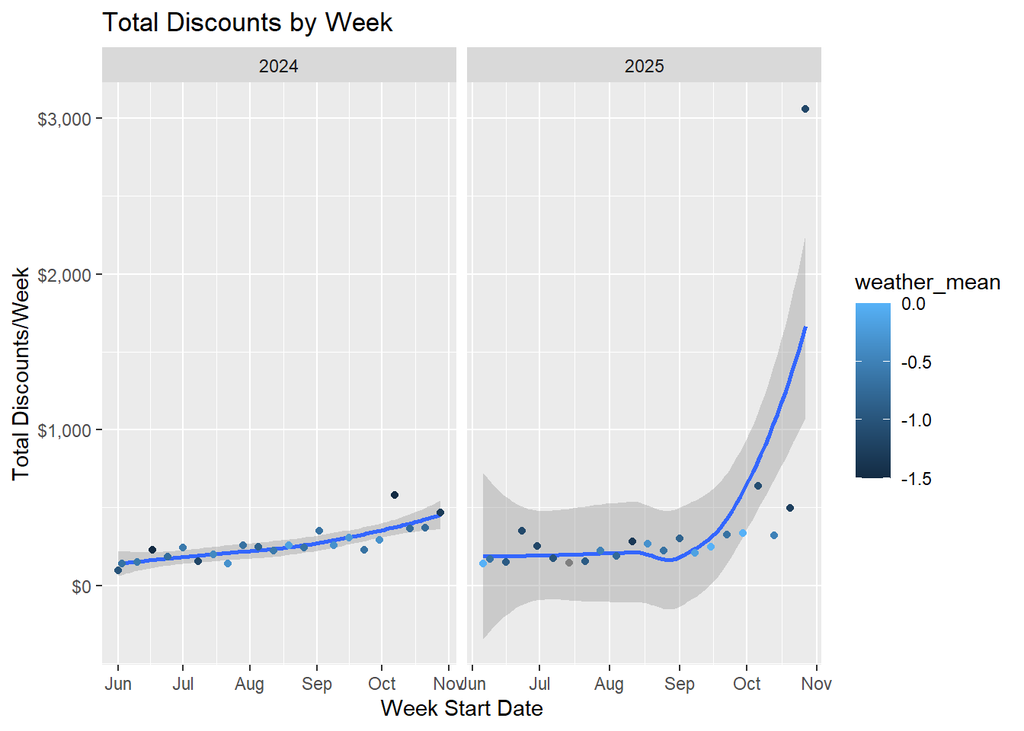

**Questions:**

- Impact analysis of higher discounting at end of 2025 seasons

## 5.5 Weekly Analysis by Category

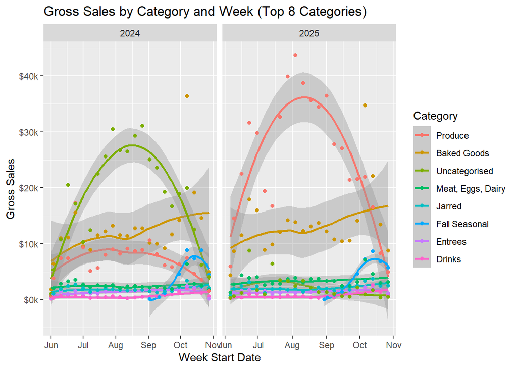

**Recommendation:**

- Categorize the items that dominate around Canadian Thanksgiving… Pies??

## 5.6 Weekly Transaction Analysis

Payment type - just a curiosity at this point.

| payment_type | n |
| --- | --- |
| Credit Card | 325671 |
| Debit Card | 198341 |
| Cash | 112338 |
| Cash, Debit Card | 309 |
| Cash, Credit Card | 242 |
| NA | 124 |
| Debit Card, Debit Card | 42 |
| Credit Card, Credit Card | 41 |
| Debit Card, Cash | 41 |
| Cash, Cash | 31 |

[output cut: 4 more lines]

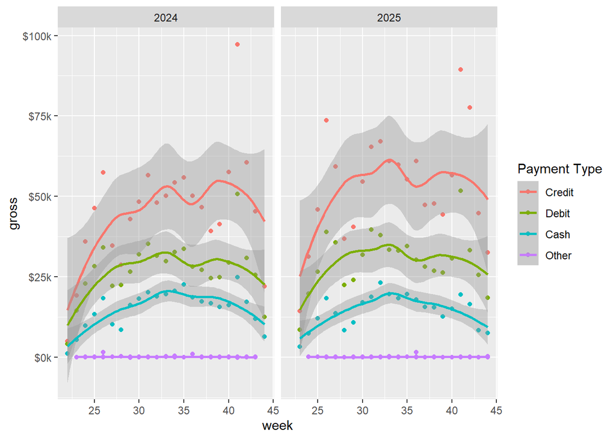

[figure not shown]

# 6 Miscellaneous Data Features

## 6.1 Discounts

| order_discount_names | n |
| --- | --- |
| NA | 617918 |
| Staff Discount | 10254 |
| End of Season | 6948 |
| 10% Off | 1176 |
| 20% Off | 246 |
| 25% Off | 117 |
| Milk Jar Deposit | 110 |
| $3.00 Off | 58 |
| 15% Off | 42 |
| $70.00 Off, 10% Off | 39 |

[output cut: 36 more lines]

## 6.2 Refunds

- Are these returns? Below are the records of refunded orders
- Omit from analysis?

| trx_type | order | order_type | order_note | date | original_date | day | week | hour | daypart | time | payment_type | payment_date | payment_time | order_amount | order_payment | order_payment_with_tips | order_payment_refund_amount | order_payment_gross_tax | order_payment_tax | order_payment_minus_refunds | order_no_of_items | order_no_of_refunded_items | order_gross | order_refund | order_total_refund | order_total_discount | order_discount_names | order_discount_percent | order_discount_amount | … |
| --- | --- | --- | --- | --- | --- | --- | --- | --- | --- | --- | --- | --- | --- | --- | --- | --- | --- | --- | --- | --- | --- | --- | --- | --- | --- | --- | --- | --- | --- | --- |
| ORDER | eb238676a37c7b15d36536363e20ef6f3b501df8a00180ca7ea278c957cdcbd6 | NA | NA | 2024-06-05 | 2024-06-05 | Wednesday | 23 | 09 (9AM) | Part 2 (08:00-10:00) | 9H 17M 0S | Cash | 2024-06-05 | 09:14 | 35.65 | 35.65 | 35.65 | 35.65 | 0 | 0 | 0 | 3.00 | 3 | 35.65 | 35.65 | 35.65 | 0 | NA | 0 | 0 | … |
| ORDER | eb238676a37c7b15d36536363e20ef6f3b501df8a00180ca7ea278c957cdcbd6 | NA | NA | 2024-06-05 | 2024-06-05 | Wednesday | 23 | 09 (9AM) | Part 2 (08:00-10:00) | 9H 17M 0S | Cash | 2024-06-05 | 09:19 | 35.65 | 35.65 | 35.65 | 35.65 | 0 | 0 | 0 | 3.00 | 3 | 35.65 | 35.65 | 35.65 | 0 | NA | 0 | 0 | … |
| ORDER | eb238676a37c7b15d36536363e20ef6f3b501df8a00180ca7ea278c957cdcbd6 | NA | NA | 2024-06-05 | 2024-06-05 | Wednesday | 23 | 09 (9AM) | Part 2 (08:00-10:00) | 9H 17M 0S | Cash | 2024-06-05 | 09:28 | 35.65 | 35.65 | 35.65 | 35.65 | 0 | 0 | 0 | 3.00 | 3 | 35.65 | 35.65 | 35.65 | 0 | NA | 0 | 0 | … |
| ORDER | eb238676a37c7b15d36536363e20ef6f3b501df8a00180ca7ea278c957cdcbd6 | NA | NA | 2024-06-05 | 2024-06-05 | Wednesday | 23 | 09 (9AM) | Part 2 (08:00-10:00) | 9H 17M 0S | Cash | 2024-06-05 | 09:18 | 35.65 | 35.65 | 35.65 | 35.65 | 0 | 0 | 0 | 3.00 | 3 | 35.65 | 35.65 | 35.65 | 0 | NA | 0 | 0 | … |
| ORDER | eb238676a37c7b15d36536363e20ef6f3b501df8a00180ca7ea278c957cdcbd6 | NA | NA | 2024-06-05 | 2024-06-05 | Wednesday | 23 | 09 (9AM) | Part 2 (08:00-10:00) | 9H 17M 0S | Cash | 2024-06-05 | 09:18 | 35.65 | 35.65 | 35.65 | 35.65 | 0 | 0 | 0 | 3.00 | 3 | 35.65 | 35.65 | 35.65 | 0 | NA | 0 | 0 | … |
| ORDER | eb238676a37c7b15d36536363e20ef6f3b501df8a00180ca7ea278c957cdcbd6 | NA | NA | 2024-06-05 | 2024-06-05 | Wednesday | 23 | 09 (9AM) | Part 2 (08:00-10:00) | 9H 17M 0S | Cash | 2024-06-05 | 09:18 | 35.65 | 35.65 | 35.65 | 35.65 | 0 | 0 | 0 | 3.00 | 3 | 35.65 | 35.65 | 35.65 | 0 | NA | 0 | 0 | … |
| ORDER | eb238676a37c7b15d36536363e20ef6f3b501df8a00180ca7ea278c957cdcbd6 | NA | NA | 2024-06-21 | 2024-06-21 | Friday | 25 | 10 (10AM) | Part 3 (10:00-14:00) | 10H 40M 0S | Cash | 2024-06-21 | 10:32 | 6.50 | 6.50 | 6.50 | 6.50 | 0 | 0 | 0 | 1.00 | 1 | 6.50 | 6.50 | 6.50 | 0 | NA | 0 | 0 | … |
| ORDER | eb238676a37c7b15d36536363e20ef6f3b501df8a00180ca7ea278c957cdcbd6 | NA | NA | 2024-06-21 | 2024-06-21 | Friday | 25 | 10 (10AM) | Part 3 (10:00-14:00) | 10H 40M 0S | Cash | 2024-06-21 | 10:40 | 6.50 | 6.50 | 6.50 | 6.50 | 0 | 0 | 0 | 1.00 | 1 | 6.50 | 6.50 | 6.50 | 0 | NA | 0 | 0 | … |
| ORDER | eb238676a37c7b15d36536363e20ef6f3b501df8a00180ca7ea278c957cdcbd6 | NA | NA | 2024-08-19 | 2024-08-19 | Monday | 34 | 13 (1PM) | Part 3 (10:00-14:00) | 13H 4M 0S | Credit Card | 2024-08-19 | 13:07 | 12.25 | 12.25 | 12.25 | 12.25 | 0 | 0 | 0 | 2.00 | 2 | 12.25 | 12.25 | 12.25 | 0 | NA | 0 | 0 | … |
| ORDER | eb238676a37c7b15d36536363e20ef6f3b501df8a00180ca7ea278c957cdcbd6 | NA | NA | 2024-08-19 | 2024-08-19 | Monday | 34 | 13 (1PM) | Part 3 (10:00-14:00) | 13H 4M 0S | Credit Card | 2024-08-19 | 13:08 | 12.25 | 12.25 | 12.25 | 12.25 | 0 | 0 | 0 | 2.00 | 2 | 12.25 | 12.25 | 12.25 | 0 | NA | 0 | 0 | … |

[output cut: 10 more lines]

## 6.3 Notes

Here is the notes field. Most from 2024. Assume no useful information here.

| note | year | n |
| --- | --- | --- |
| Tomato Baskets | 2024 | 10 |
| Beets | 2024 | 4 |
| carrots | 2024 | 4 |
| Honest Realtors Deposit | 2024 | 2 |
| Soup box | 2024 | 2 |
| Delivery | 2024 | 1 |
| MSH 125 Adult Admission | 2024 | 1 |
| 5 box tomatoes | 2025 | 2 |
| 6.95 | 2025 | 1 |